# Assignment 1

To start, we will import some packages that we would use to read and manipulate our data set.

```python
import pandas as pd
import numpy as np
import matplotlib.pyplot as plt
import seaborn as sns
import math
import dateutil
from geopy.geocoders import Nominatim
import folium
from statsmodels.graphics.mosaicplot import mosaic
```

Next, we import the data that we want to explore which is stored in "survey.csv". It contains the responses to question from a mental health survey.

```python
df = pd.read_csv('survey.csv')
```

It is important for us to know the number of participants(rows) and features(columns) captured in the data set. Following this, we must know the data types of the features. This information could potentially guide the decisions we will make when cleaning the data.

```python
df.shape
```

```
(1259, 27)
```

```python
df.dtypes
```

```
Timestamp                    object
Age                           int64
Gender                       object
Country                      object
state                        object
self_employed                object
family_history               object
treatment                    object
work_interfere               object
no_employees                 object
remote_work                  object
tech_company                 object
benefits                     object
care_options                 object
wellness_program             object
seek_help                    object
anonymity                    object
leave                        object
mental_health_consequence    object
phys_health_consequence      object
coworkers                    object
supervisor                   object
mental_health_interview      object
phys_health_interview        object
mental_vs_physical           object
obs_consequence              object
comments                     object
dtype: object
```

Given that all columns, with the exception of age are object, we need to have a closer look at what data is actually in the file. To do this, we will peak at the first few rows of the file.

```python
df.head()
```

|  | Timestamp | Age | Gender | Country | state | self_employed | family_history | treatment | work_interfere | no_employees | ... | leave | mental_health_consequence | phys_health_consequence | coworkers | supervisor | mental_health_interview | phys_health_interview | mental_vs_physical | obs_consequence | comments |
| --- | --- | --- | --- | --- | --- | --- | --- | --- | --- | --- | --- | --- | --- | --- | --- | --- | --- | --- | --- | --- | --- |
| 0 | 2014-08-27 11:29:31 | 37 | Female | United States | IL | NaN | No | Yes | Often | 6-25 | ... | Somewhat easy | No | No | Some of them | Yes | No | Maybe | Yes | No | NaN |
| 1 | 2014-08-27 11:29:37 | 44 | M | United States | IN | NaN | No | No | Rarely | More than 1000 | ... | Don't know | Maybe | No | No | No | No | No | Don't know | No | NaN |
| 2 | 2014-08-27 11:29:44 | 32 | Male | Canada | NaN | NaN | No | No | Rarely | 6-25 | ... | Somewhat difficult | No | No | Yes | Yes | Yes | Yes | No | No | NaN |
| 3 | 2014-08-27 11:29:46 | 31 | Male | United Kingdom | NaN | NaN | Yes | Yes | Often | 26-100 | ... | Somewhat difficult | Yes | Yes | Some of them | No | Maybe | Maybe | No | Yes | NaN |
| 4 | 2014-08-27 11:30:22 | 31 | Male | United States | TX | NaN | No | No | Never | 100-500 | ... | Don't know | No | No | Some of them | Yes | Yes | Yes | Don't know | No | NaN |

5 rows × 27 columns

We notice that the other columns are textual and that there are missing values. The self_employed column head does not give any idea of what we might expect here. We will probe into it later. For the others, the object data type may not affect our analysis. We also need to look closer at the timestamp column. Due to the closeness of the values in the head, we might assume it is simply the date and time the form was submitted.

```python
set(val[0:10] for val in df['Timestamp'])
```

```
{'2014-08-27',
 '2014-08-28',
 '2014-08-29',
 '2014-08-30',
 '2014-08-31',
 '2014-09-01',
 '2014-09-02',
 '2014-09-03',
 '2014-09-04',
 '2014-09-05',
 '2014-09-08',
 '2014-09-09',
 '2014-09-11',
 '2014-09-12',
 '2014-09-13',
 '2014-09-14',
 '2014-09-20',
 '2014-09-23',
 '2014-09-26',
 '2014-09-30',
 '2014-10-02',
 '2014-10-05',
 '2014-10-09',
 '2014-11-05',
 '2014-11-06',
 '2014-11-16',
 '2014-12-01',
 '2014-12-15',
 '2015-01-03',
 '2015-02-21',
 '2015-02-22',
 '2015-02-24',
 '2015-02-26',
 '2015-04-02',
 '2015-04-04',
 '2015-04-06',
 '2015-04-11',
 '2015-04-23',
 '2015-05-05',
 '2015-05-06',
 '2015-05-07',
 '2015-06-25',
 '2015-07-22',
 '2015-07-27',
 '2015-08-17',
 '2015-08-20',
 '2015-08-25',
 '2015-09-12',
 '2015-09-26',
 '2015-11-07',
 '2015-11-30',
 '2016-02-01'}
```

This indicates that the data was collected between late August 2014 and early February 2016. This may not hold any relevance depending on what we are looking for. Let's change it's data type to datetime, just in case.

```python
df['Timestamp'] = df['Timestamp'].apply(dateutil.parser.parse)
```

```python
df.dtypes
```

```
Timestamp                    datetime64[ns]
Age                                   int64
Gender                               object
Country                              object
state                                object
self_employed                        object
family_history                       object
treatment                            object
work_interfere                       object
no_employees                         object
remote_work                          object
tech_company                         object
benefits                             object
care_options                         object
wellness_program                     object
seek_help                            object
anonymity                            object
leave                                object
mental_health_consequence            object
phys_health_consequence              object
coworkers                            object
supervisor                           object
mental_health_interview              object
phys_health_interview                object
mental_vs_physical                   object
obs_consequence                      object
comments                             object
dtype: object
```

Now, let's see if any columns are totally empty.

```python
all_nan = df.columns[df.isnull().all()]
list(all_nan)
```

```
[]
```

There are no empty columns. Let's get a definitive list of columns with ANY missing values as well.

```python
any_nan = df.columns[df.isnull().any()]
list(any_nan)
```

```
['state', 'self_employed', 'work_interfere', 'comments']
```

State is expected to be missing some values as this only applies to responses from USA. Comments are also expected to be missing values as it is most likely optional free text. Let's see how many rows are missing values for self_employed and work_interfere. We would also like seeing the unique responses to these questions.

```python
set(df['self_employed'])
```

```
{nan, 'No', 'Yes'}
```

```python
set(df['work_interfere'])
```

```
{nan, 'Rarely', 'Never', 'Sometimes', 'Often'}
```

```python
miss = df[(df['work_interfere'].isnull())
          | (df['self_employed'].isnull())]
```

```python
miss.shape
```

```
(282, 27)
```

282 rows are missing values for the 2 fields. We should check if they overlap to see if this is related somehow.

```python
overlap = miss[(miss['work_interfere'].isnull())
          & (miss['self_employed'].isnull())]
overlap.shape
```

```
(0, 27)
```

Given that there is no overlap, let's examine the different occurences.

```python
miss_set = miss[['work_interfere','self_employed']].drop_duplicates()
miss_set
```

|  | work_interfere | self_employed |
| --- | --- | --- |
| 0 | Often | NaN |
| 1 | Rarely | NaN |
| 4 | Never | NaN |
| 5 | Sometimes | NaN |
| 19 | NaN | Yes |
| 26 | NaN | No |

Seems there is no obvious relationship between the 2. For now, we will not attempt to fill these but we can't delete the rows as they make up a large portion of our data and can be useful as the other fields are filled.As age is the only numerical column, let us examine some descriptive statistics about it.

```python
df['Age'].describe()
```

```
count    1.259000e+03
mean     7.942815e+07
std      2.818299e+09
min     -1.726000e+03
25%      2.700000e+01
50%      3.100000e+01
75%      3.600000e+01
max      1.000000e+11
Name: Age, dtype: float64
```

Immediately, we notice the minimum age is below 0 and the maximum is well over 1000. These values are most likely erroneous and could skew our findings. Let's check how many rows have these outliers in them.

```python
err_ages = df.query('Age<0 or Age>150')
err_ages.shape
```

```
(5, 27)
```

As it is only 5 rows out of 1259 (< 1% of records), we can remove them.

```python
df = df.query('Age>=0 and Age<150')
df.shape
```

```
(1254, 27)
```

Now we may re-examine the age stats.

```python
df['Age'].describe()
```

```
count    1254.000000
mean       32.019139
std         7.375005
min         5.000000
25%        27.000000
50%        31.000000
75%        36.000000
max        72.000000
Name: Age, dtype: float64
```

Question 2. Now that all ages lie between 5 and 75, we can plot the age distribution.

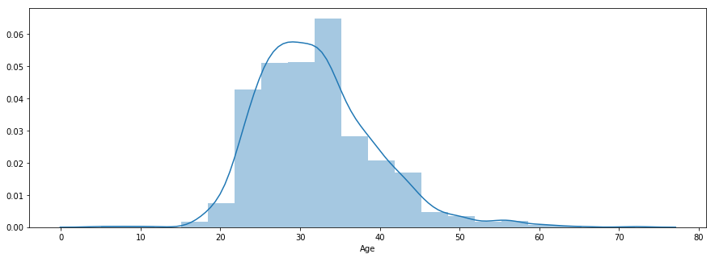

```python
plt.subplots(figsize=(15,5))
sns.distplot(df['Age'],bins=20)
plt.show()
```

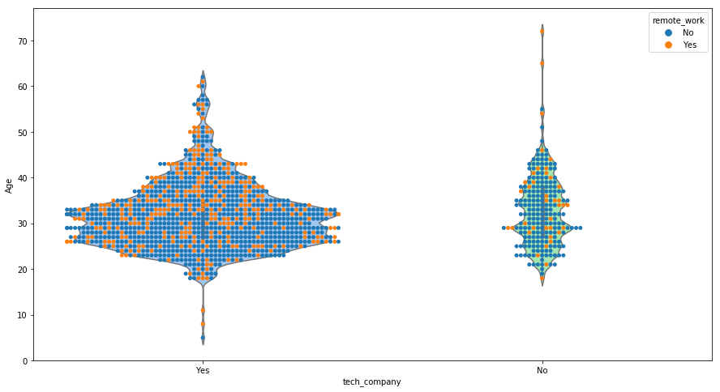

```python
plt.subplots(figsize=(15,8))
sns.violinplot(x="tech_company", y="Age", data=df,
               bw=.1, scale="count", palette='pastel');
sns.swarmplot(x="tech_company", y="Age", hue="remote_work", data=df, alpha=1);
plt.show()
```

Just wanted to see if working in a tech company was related to whether or not employees work remotely. It seems like tech companies have a higher percentage of employees who work from home than non-tech companies.Question3. We should get an idea of how this data looks per country. First, we'll count how many entries there are for all countries.

```python
country_agg = (df.groupby('Country')[['Age']].count())
country_agg['Country'] = country_agg.index
country_agg.rename(columns={'Age':'count'},inplace=True)
country_agg.describe()
```

|  | count |
| --- | --- |
| count | 47.000000 |
| mean | 26.680851 |
| std | 111.294577 |
| min | 1.000000 |
| 25% | 1.000000 |
| 50% | 3.000000 |
| 75% | 7.000000 |
| max | 748.000000 |

```python
#please wait a minute and re-run this step if it fails.
#geopy sometimes thros an error for what seems to be too many requests.
geolocator = Nominatim()

country_top10 = country_agg.nlargest(10,'count')
countries  = pd.DataFrame({'Country':list(country_top10['Country'])})

names = []
lats = []
longs = []

print('Fetching countries, please wait...')
for c in list(countries['Country']):
   geo = geolocator.geocode(c)
   names.append(c)
   lats.append(geo.latitude)
   longs.append(geo.longitude)
   print('...')
print('Done!')

geo_df = pd.DataFrame({'Country':names,'longitude':longs,'latitude':lats})
df_coords = pd.merge(country_agg,geo_df,how='inner',on='Country')

map = folium.Map(location=[20,0], tiles='Mapbox Bright', zoom_start=1.5)
for i in range(0,10):
    row = df_coords.iloc[i]
    folium.Circle(
        location=[row['latitude'],row['longitude']],
        popup=row['Country'],
        radius=str(row['count']*1000),
        color='crimson',
        fill=True,
        fill_color='crimson'
    ).add_to(map)
map
```

```
Fetching countries, please wait...
...
...
...
...
...
...
...
...
...
...
Done!
```

[interactive chart not shown]

We can see based on the radius of the red circles that the most responses were recorded in the United States, United Kingdom and Canada respectively. If this data set is a representative sample of the world, it would seem to indicate that these countries, in the order listed, have the highest prevalence of mental health issues.Question 4 and 5 Now we will look at the role that family history has to play in individuals with mental health issues. First, we get an idea of the values of this column.

```python
set(df['family_history'])
```

```
{'No', 'Yes'}
```

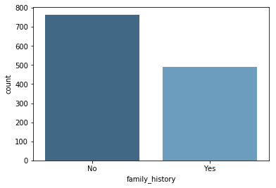

```python
sns.countplot(x='family_history', data=df, palette="Blues_d")
plt.show()
```

From this, we can see, that the majority of people with mental issues actually did not have history of it in their family.Questions 6 Let's look at the values of the columns of interest to see if they require massaging.

```python
print(set(df['mental_vs_physical']))
print(set(df['benefits']))
print(set(df['no_employees']))
```

```
{'No', 'Yes', "Don't know"}
{'No', 'Yes', "Don't know"}
{'6-25', 'More than 1000', '1-5', '26-100', '100-500', '500-1000'}
```

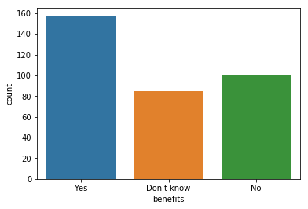

```python
sns.countplot(x='benefits', data=df[df['mental_vs_physical']=='Yes'])
plt.show()
```

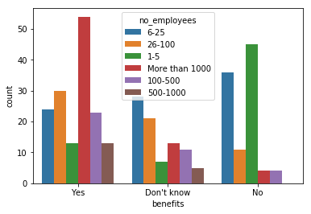

```python
sns.countplot(x='benefits', data=df[df['mental_vs_physical']=='Yes'],hue='no_employees')
plt.show()
```

It seems like the larger companies with over 25 employees, have the highest presence and awareness of mental health issues benefits.

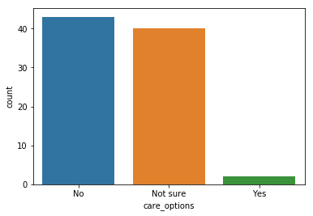

```python
sns.countplot(x='care_options', data=df[
    (df['mental_vs_physical']=='Yes') &
    (df['benefits'] == "Don't know")] )
plt.show()
```

Those who don't know if their employer has benefits, neither know about care options. This could be an area to investigate for these companies as their employees may benefit from an education drive.Question 7 The histogram below shows that most people think it is either somewhat easy or very easy to take leave for mental health issues in companies that take it seriously. This could suggest that the companies support their employees through the challenges presented by their mental health issues.

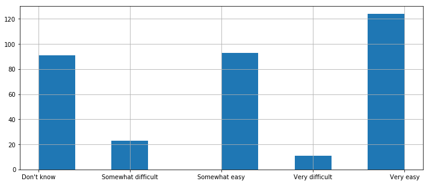

```python
(df[df['mental_vs_physical'] == "Yes"])['leave'].hist(figsize=(12,5))
plt.show()
```

Question 8 and 9 There seems to be an almost even number of people receiving treatment vs those who are not

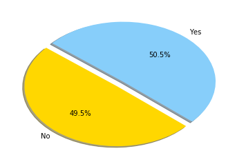

```python
treat_agg = (df.groupby('treatment')[['Age']].count())
treat_agg['treatment'] = treat_agg.index
treat_agg.rename(columns={'Age':'count'},inplace=True)

plt.pie(treat_agg['count'],explode=(0.1,0),labels=treat_agg['treatment'],
        colors=['gold','lightskyblue'],autopct='%1.1f%%', shadow=True, startangle=140)

plt.show()
```

Question 10

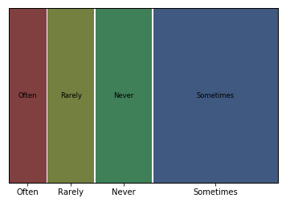

```python
mosaic(df,['work_interfere'])
plt.show()
```

Most people in the survey say that their mental health affects their work atleast sometimes. The minority, what looks like around 20% of the people clain they are never affected.